# Air Quality in Southampton (UK)

# 5 Oxides of Nitrogen (nox)

```r
yLab <- "Oxides of Nitrogen (ug/m3)"
noxdt <- aurnDT[pollutant == "nox"]
```

Figure 5.1 shows the availability of this data over time.

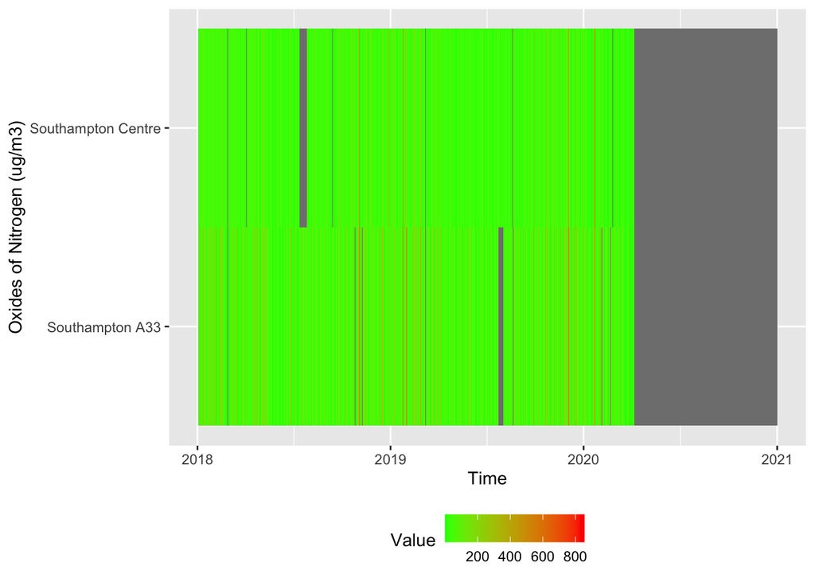

Figure 5.1: Oxides of nitrogen data availability and levels over time

```r
# dt,xvar, yvar,fillVar, yLab
p <- makeTilePlot(noxdt, xVar = "dateTimeUTC", yVar = "site", fillVar = "value", yLab = yLab)

p
```

# 6 Sulphour Dioxide

```r
yLab <- "Sulphour Dioxide (ug/m3)"
so2dt <- aurnDT[pollutant == "so2"]
```

Figure 6.1 shows the availability of this data over time.

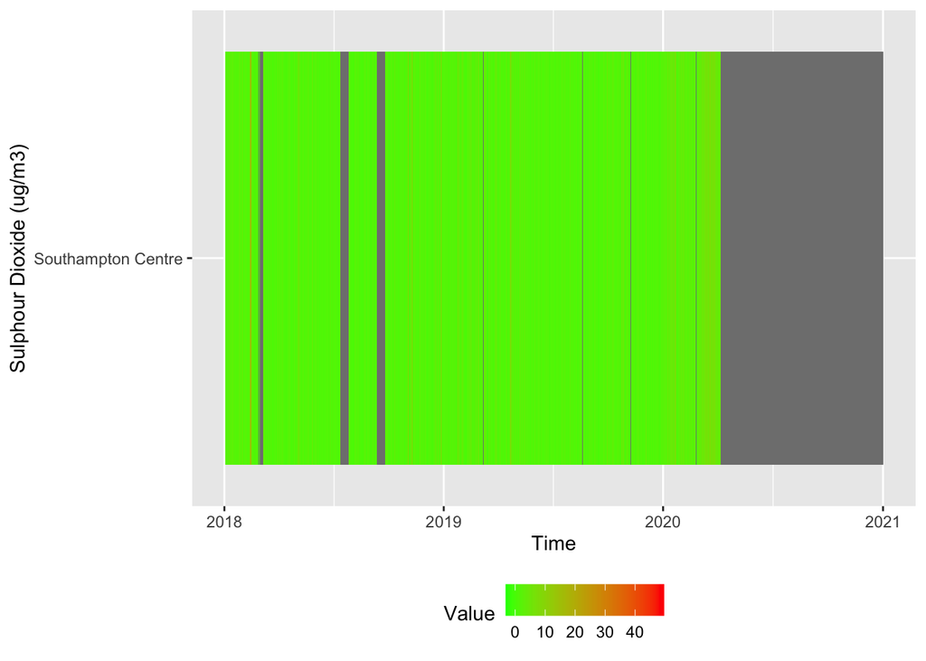

Figure 6.1: Sulphour Dioxide data availability and levels over time

```r
# dt,xvar, yvar,fillVar, yLab
p <- makeTilePlot(so2dt, xVar = "dateTimeUTC", yVar = "site", fillVar = "value", yLab = yLab)

p
```

# 7 Ozone

```r
yLab <- "Ozone (ug/m3)"
o3dt <- aurnDT[pollutant == "o3"]
```

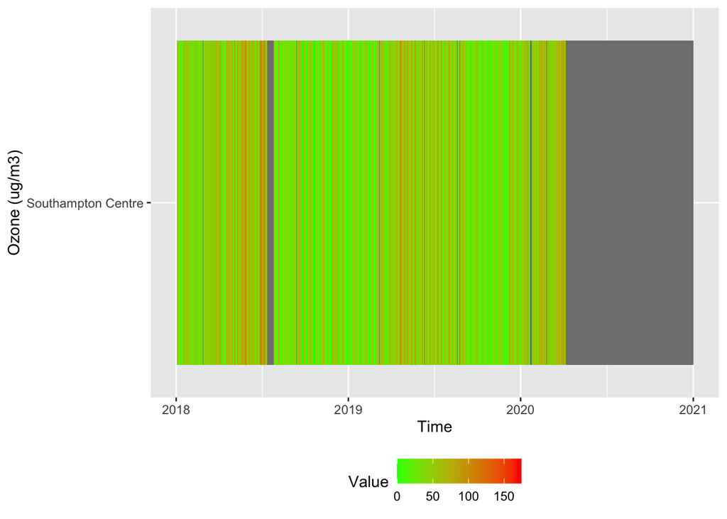

Figure 7.1: Availability and level of o3 data over time

```r
p <- makeTilePlot(o3dt, xVar = "dateTimeUTC", yVar = "site", fillVar = "value", yLab = yLab)

p
```

# 8 PM 10

```r
yLab <- "PM 10 (ug/m3)"
pm10dt <- aurnDT[pollutant == "pm10"]
```

Figure 8.1 shows the availability of data over time.

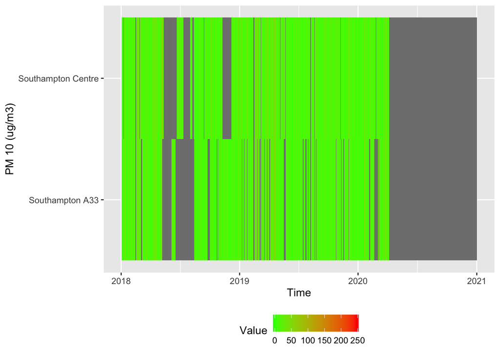

```r
p <- makeTilePlot(pm10dt, xVar = "dateTimeUTC", yVar = "site", fillVar = "value", yLab = yLab)

p
```

# 9 PM 2.5

```r
yLab <- "PM 2.5 (ug/m3)"
pm25dt <- aurnDT[pollutant == "pm2.5"]
```

Figure 9.1 shows the availability of data over time.

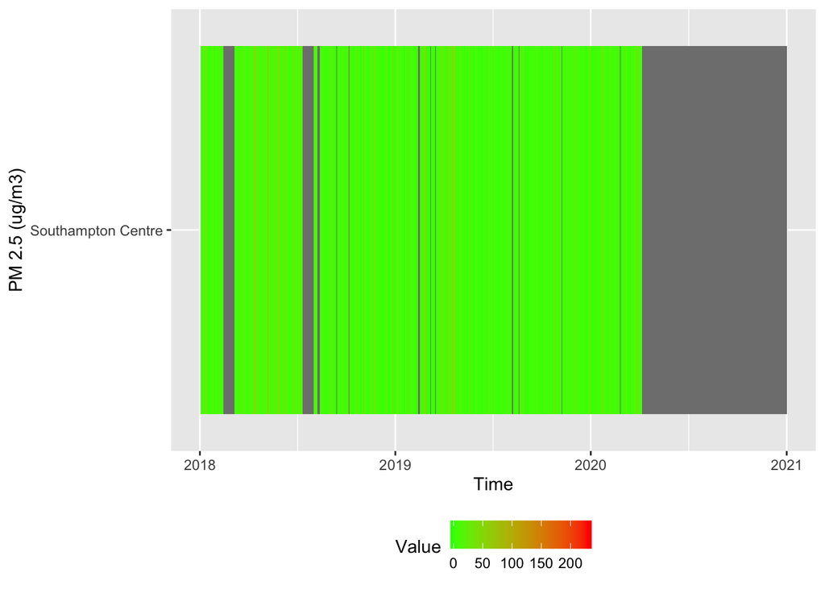

```r
p <- makeTilePlot(pm25dt, xVar = "dateTimeUTC", yVar = "site", fillVar = "value", yLab = yLab)

p
```

## 9.1 Wind speed

```r
yLab <- "Wind speed (m/s)"
wsdt <- aurnDT[pollutant == "windSpeed"]
```

Figure 9.2 shows the availability of data over time.

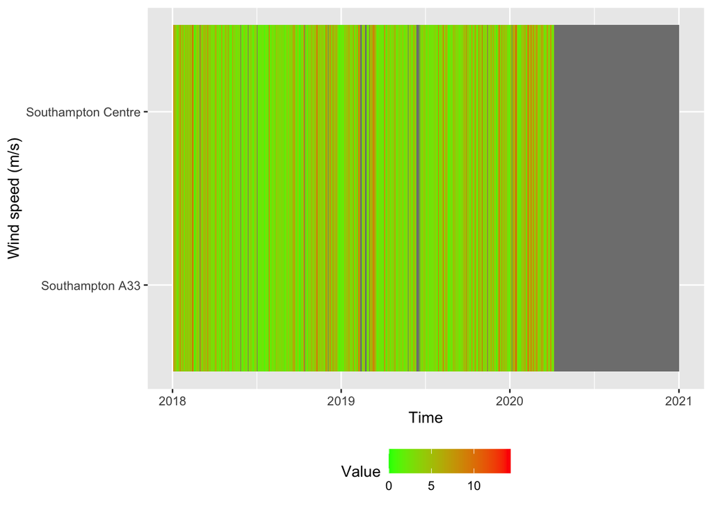

Figure 9.2: Availability and level of wind speed data over time

```r
p <- makeTilePlot(wsdt, xVar = "dateTimeUTC", yVar = "site", fillVar = "value", yLab = yLab)

p
```

## 9.2 Wind direction

```r
yLab <- "Wind direction (deg)"
wddt <- aurnDT[pollutant == "windDirection"]
```

Figure 9.3 shows the availability of data over time.

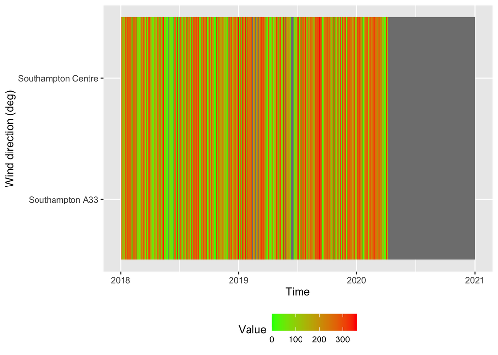

Figure 9.3: Availability and level of wind direction data over time

```r
p <- makeTilePlot(wddt, xVar = "dateTimeUTC", yVar = "site", fillVar = "value", yLab = yLab)

p
```

# 10 Save data

Save long form data to data folder.

```r
aurnDT[, `:=`(weekDay, lubridate::wday(dateTimeUTC, label = TRUE, abbr = TRUE))]
f <- paste0(here::here(), "/data/sotonExtract2018_2020.csv")
data.table::fwrite(aurnDT, f)
```

Saved data description:

```r
skimr::skim(aurnDT)
```

Table 10.1: Data summary

| Name | aurnDT |
| --- | --- |
| Number of rows | 516744 |
| Number of columns | 9 |
| _______________________ |  |
| Column type frequency: |  |
| character | 5 |
| Date | 1 |
| factor | 1 |
| numeric | 1 |
| POSIXct | 1 |
| ________________________ |  |
| Group variables | None |

**Variable type: character**

| skim_variable | n_missing | complete_rate | min | max | empty | n_unique | whitespace |
| --- | --- | --- | --- | --- | --- | --- | --- |
| date | 0 | 1 | 20 | 20 | 0 | 26280 | 0 |
| code | 0 | 1 | 4 | 4 | 0 | 2 | 0 |
| site | 0 | 1 | 15 | 18 | 0 | 2 | 0 |
| pollutant | 0 | 1 | 2 | 13 | 0 | 13 | 0 |
| source | 0 | 1 | 4 | 4 | 0 | 1 | 0 |

**Variable type: Date**

| skim_variable | n_missing | complete_rate | min | max | median | n_unique |
| --- | --- | --- | --- | --- | --- | --- |
| obsDate | 0 | 1 | 2018-01-02 | 2020-12-31 | 2019-05-29 | 1095 |

**Variable type: factor**

| skim_variable | n_missing | complete_rate | ordered | n_unique | top_counts |
| --- | --- | --- | --- | --- | --- |
| weekDay | 0 | 1 | TRUE | 7 | Tue: 74136, Wed: 74040, Thu: 74040, Sun: 73632 |

**Variable type: numeric**

| skim_variable | n_missing | complete_rate | mean | sd | p0 | p25 | p50 | p75 | p100 | hist |
| --- | --- | --- | --- | --- | --- | --- | --- | --- | --- | --- |
| value | 147233 | 0.72 | 38.83 | 70.44 | -9.4 | 4 | 11.68 | 34.52 | 855.62 | ▇▁▁▁▁ |

**Variable type: POSIXct**

| skim_variable | n_missing | complete_rate | min | max | median | n_unique |
| --- | --- | --- | --- | --- | --- | --- |
| dateTimeUTC | 0 | 1 | 2018-01-02 | 2020-12-31 23:00:00 | 2019-05-29 15:00:00 | 26280 |

# 11 Annex

# 12 Runtime

Report generated using knitr in [RStudio](http://www.rstudio.com) with R version 3.6.3 (2020-02-29) running on x86_64-apple-darwin15.6.0 (Darwin Kernel Version 19.4.0: Wed Mar 4 22:28:40 PST 2020; root:xnu-6153.101.6~15/RELEASE_X86_64).

```r
t <- proc.time() - myParams$startTime

elapsed <- t[[3]]
```

Analysis completed in 65.358 seconds ( 1.09 minutes).

R packages used:

- data.table - (Dowle et al. 2015)
- ggplot2 - (Wickham 2009)
- here - (Müller 2017)
- kableExtra - (Zhu 2018)
- lubridate - (Grolemund and Wickham 2011)
- skimr - (Arino de la Rubia et al. 2017)
- viridis - (Garnier 2018)

# References

Arino de la Rubia, Eduardo, Hao Zhu, Shannon Ellis, Elin Waring, and Michael Quinn. 2017. *Skimr: Skimr*. https://github.com/ropenscilabs/skimr.

Dowle, M, A Srinivasan, T Short, S Lianoglou with contributions from R Saporta, and E Antonyan. 2015. *Data.table: Extension of Data.frame*. https://CRAN.R-project.org/package=data.table.

Garnier, Simon. 2018. *Viridis: Default Color Maps from ’Matplotlib’*. https://CRAN.R-project.org/package=viridis.

Grolemund, Garrett, and Hadley Wickham. 2011. “Dates and Times Made Easy with lubridate.” *Journal of Statistical Software* 40 (3): 1–25. http://www.jstatsoft.org/v40/i03/.

Müller, Kirill. 2017. *Here: A Simpler Way to Find Your Files*. https://CRAN.R-project.org/package=here.

Wickham, Hadley. 2009. *Ggplot2: Elegant Graphics for Data Analysis*. Springer-Verlag New York. http://ggplot2.org.

Zhu, Hao. 2018. *KableExtra: Construct Complex Table with ’Kable’ and Pipe Syntax*. https://CRAN.R-project.org/package=kableExtra.